# Hypatia

Single-Cell RNA Isoform Analysis

Author

Timothy Pan

Published

10/13/26

# Background

RNA isoforms expand the coding genome and have significant implications in health and disease. Long-read single-cell RNA-sequencing (LR-scRNAseq) enables the investigation of RNA isoforms at cell type resolution. Hypatia is a computational suite in R to support isoform analysis across 3 modules: 1) isoform usage, which identifies differential isoform usage (DIU) events, 2) isoform diversity, which identifies differential isoform diversity (DIV) events, and 3) isoform expression, which identifies differentially expressed isoform (DEI) events.

Check out our [*preprint*](https://www.biorxiv.org/content/10.64898/2026.01.13.699341v2) for more details on Hypatia. If you found this tool useful in your research, please remember to cite us:

```
Pan, T., Shiau, C. K., Lu, L., Wang, C., Wang, M., He, Y., Bhimaraj, A., Brat, D., Huse, J.,
Li, J., & Gao, R. (2026). Hypatia: Comparative Isoform Profiling Across Cell Populations
 from Long-Read Single-Cell Transcriptomes. bioRxiv : the preprint server for biology,
 2026.01.13.699341. https://doi.org/10.64898/2026.01.13.699341
```

# Installation

Hypatia is an R package available through GitHub:

```r
if (!requireNamespace("devtools", quietly = TRUE)) {
  install.packages("devtools")
}

devtools::install_github("gaolabtools/Hypatia")
```

Hypatia requires R 4.1 or later. The following dependencies will be installed if they are not already present: checkmate, dplyr (>= 1.0.0), ggnewscale, ggplot2 (>= 3.5.0), GenomicRanges, Matrix, patchwork, purrr, S4Vectors, SingleCellExperiment, SummarizedExperiment, tibble, tidyr, and matrixTests.

# Input data

Hypatia requires 3 inputs:

1. **Single-cell isoform expression matrix**

   A numeric data frame, dense matrix, or sparse `dgCMatrix` of finite, non-negative raw isoform counts with no missing values. Row names are unique transcript IDs and column names are unique cell IDs.
2. **Cell-level metadata**

   A data frame with at least one column of cell annotations (cell types, clusters) necessary for differential analysis. Row names are cell IDs matching the count matrix.
3. **Transcript-level metadata**

   A data frame with at least one column containing gene identifiers associated with transcripts in the count matrix. Row names are transcript IDs matching the count matrix.

## Tutorial data

For the tutorial, we analyze single-cell long-read RNA-seq data of a human glioblastoma (GBM) tumor. Raw reads were processed using [*scNanoGPS*](https://github.com/gaolabtools/scNanoGPS), in which [*IsoQuant*](https://github.com/ablab/IsoQuant) performed isoform quantification. Gene expression data were analyzed beforehand in [*Seurat*](https://satijalab.org/seurat/), revealing 8 cell types: astrocytes, oligodendrocytes, oligodendrocyte precursor cells (OPCs), tumor, microglia, vascular, GABAergic neurons (GABA neuron), and glutamatergic neurons (Glut neuron):

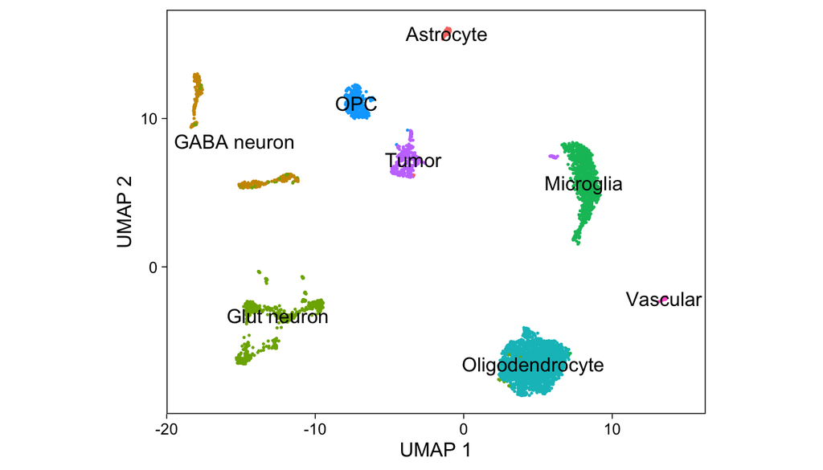

Gene-expression UMAP of the GBM tutorial cells, colored by the eight cell-type annotations used for isoform analysis.

The following input data for the tutorial is available (lazy-loaded) after the package is loaded into the environment:

- `gbm_countData`: The raw single-cell isoform expression matrix consisting of 56,642 isoforms from 5,043 cells.
- `gbm_colData`: The cell-level metadata containing the columns `cell_type`, `umap_1`, and `umap_2` derived from gene expression analysis.
- `gbm_rowData`: The transcript-level metadata with columns `gene_id`, `gene_name`, and `transcript_name`. Also contains various isoform QC metrics from [*SQANTI3*](https://github.com/ConesaLab/SQANTI3) pipeline (*strongly recommended*)
- `gbm_gtf`: Transcript structure file for reference.

```r
library(Hypatia)

gbm_countData
gbm_colData
gbm_rowData
gbm_gtf
```

**gbm_countData**

```r
str(gbm_countData)
## Formal class 'dgCMatrix' [package "Matrix"] with 6 slots
##   ..@ i       : int [1:934559] 77 189 393 406 499 577 719 1340 1394 1566 ...
##   ..@ p       : int [1:5044] 0 256 985 1365 1416 1554 1828 2021 2145 2671 ...
##   ..@ Dim     : int [1:2] 56642 5043
##   ..@ Dimnames:List of 2
##   .. ..$ : chr [1:56642] "ENST00000008440" "ENST00000040877" "ENST00000054666" "ENST00000060969" ...
##   .. ..$ : chr [1:5043] "GCCACAACATCGGTTC" "TCGGGCATCACCAGTA" "CCGAATTGTAGCTCGC" "CTGCATGGTTGGATAG" ...
##   ..@ x       : num [1:934559] 1 1 1 1 1 1 1 1 1 1 ...
##   ..@ factors : list()
```

**gbm_colData**

```r
str(gbm_colData)
## 'data.frame':    5043 obs. of  3 variables:
##  $ cell_type: chr  "Microglia" "Glut neuron" "GABA neuron" "Oligodendrocyte" ...
##  $ umap_1   : num  7.58 -14.63 -12.36 5.86 8.17 ...
##  $ umap_2   : num  1.97 -6.25 5.92 -7.23 7.03 ...
```

**gbm_rowData**

```r
str(gbm_rowData)
## 'data.frame':    56642 obs. of  7 variables:
##  $ structural_category: chr  "full-splice_match" "full-splice_match" "full-splice_match" "full-splice_match" ...
##  $ gene_id            : chr  "ENSG00000010072" "ENSG00000059588" "ENSG00000049245" "ENSG00000052723" ...
##  $ RTS_stage          : logi  FALSE FALSE FALSE FALSE FALSE FALSE ...
##  $ within_CAGE_peak   : logi  TRUE TRUE TRUE TRUE FALSE TRUE ...
##  $ within_polyA_site  : logi  TRUE TRUE TRUE TRUE TRUE TRUE ...
##  $ gene_name          : chr  "SPRTN" "TARBP1" "VAMP3" "SIKE1" ...
##  $ transcript_name    : chr  "SPRTN-201" "TARBP1-201" "VAMP3-201" "SIKE1-201" ...
```

**gbm_gtf**

```r
str(gbm_gtf)
## Formal class 'GRanges' [package "GenomicRanges"] with 7 slots
##   ..@ seqnames       :Formal class 'Rle' [package "S4Vectors"] with 4 slots
##   .. .. ..@ values         : Factor w/ 44 levels "chr1","chr2",..: 1 2 3 4 5 6 7 8 9 10 ...
##   .. .. ..@ lengths        : int [1:37] 34923 28622 23645 14941 17499 18314 18894 13275 14544 15243 ...
##   .. .. ..@ elementMetadata: NULL
##   .. .. ..@ metadata       : list()
##   ..@ ranges         :Formal class 'IRanges' [package "IRanges"] with 6 slots
##   .. .. ..@ start          : int [1:365784] 14404 14404 14970 15796 14404 14404 14970 15796 16607 16858 ...
##   .. .. ..@ width          : int [1:365784] 2038 426 69 646 5002 426 69 152 159 198 ...
##   .. .. ..@ NAMES          : NULL
##   .. .. ..@ elementType    : chr "ANY"
##   .. .. ..@ elementMetadata: NULL
##   .. .. ..@ metadata       : list()
##   ..@ strand         :Formal class 'Rle' [package "S4Vectors"] with 4 slots
##   .. .. ..@ values         : Factor w/ 3 levels "+","-","*": 2 1 2 1 2 1 2 1 2 1 ...
##   .. .. ..@ lengths        : int [1:9942] 121 13 10 29 58 20 15 3 34 13 ...
##   .. .. ..@ elementMetadata: NULL
##   .. .. ..@ metadata       : list()
##   ..@ seqinfo        :
## Formal class 'Seqinfo' [package "GenomeInfoDb"] with 4 slots
##   .. .. ..@ seqnames   : chr [1:44] "chr1" "chr2" "chr3" "chr4" ...
##   .. .. ..@ seqlengths : int [1:44] NA NA NA NA NA NA NA NA NA NA ...
##   .. .. ..@ is_circular: logi [1:44] NA NA NA NA NA NA ...
##   .. .. ..@ genome     : chr [1:44] NA NA NA NA ...
##   ..@ elementMetadata:Formal class 'DFrame' [package "S4Vectors"] with 6 slots
##   .. .. ..@ rownames       : NULL
##   .. .. ..@ nrows          : int 365784
##   .. .. ..@ elementType    : chr "ANY"
##   .. .. ..@ elementMetadata: NULL
##   .. .. ..@ metadata       : list()
##   .. .. ..@ listData       :List of 7
##   .. .. .. ..$ source       : Factor w/ 3 levels "HAVANA","IsoQuant",..: 2 2 2 2 2 2 2 2 2 2 ...
##   .. .. .. ..$ type         : Factor w/ 2 levels "transcript","exon": 1 2 2 2 1 2 2 2 2 2 ...
##   .. .. .. ..$ score        : num [1:365784] NA NA NA NA NA NA NA NA NA NA ...
##   .. .. .. ..$ phase        : int [1:365784] NA NA NA NA NA NA NA NA NA NA ...
##   .. .. .. ..$ transcript_id: chr [1:365784] "transcript140.chr1.nnic" "transcript140.chr1.nnic" "transcript140.chr1.nnic" "transcript140.chr1.nnic" ...
##   .. .. .. ..$ gene_id      : chr [1:365784] "novel_gene_chr1_8" "novel_gene_chr1_8" "novel_gene_chr1_8" "novel_gene_chr1_8" ...
##   .. .. .. ..$ gene_name    : chr [1:365784] NA NA NA NA ...
##   ..@ elementType    : chr "ANY"
##   ..@ metadata       : list()
```

For the detailed code used to prepare the individual metadata, see Extras.

# 1. Create the *SCE* object

## CreateSCE

Hypatia uses the [*SingleCellExperiment*](https://www.bioconductor.org/packages/devel/bioc/vignettes/SingleCellExperiment/inst/doc/intro.html) object, which provides a standardized framework for storing and organizing single-cell data. After the input data are prepared, the *SCE* object can be created using the function `CreateSCE()`.

```r
library(Hypatia)

# Create the SCE
gbm <- CreateSCE(
  countData = gbm_countData,
  colData = gbm_colData,
  rowData = gbm_rowData
)
```

```r
gbm
## class: SingleCellExperiment
## dim: 56642 5043
## metadata(3): active.gene.id active.group.id active.transcript.id
## assays(1): counts
## rownames(56642): ENST00000008440 ENST00000040877 ...
##   transcript29.KI270742.1.nnic transcript71.KI270742.1.nnic
## rowData names(8): nCell structural_category ... gene_name
##   transcript_name
## colnames(5043): GCCACAACATCGGTTC TCGGGCATCACCAGTA ... AAGTCACCATTAACCT
##   CCCGATAGTGATTCCG
## colData names(7): project nCount ... umap_1 umap_2
## reducedDimNames(0):
## mainExpName: NULL
## altExpNames(0):
```

1. By default, `CreateSCE()` searches for a column called `"gene_id"` in `rowData` for associated genes. This can be changed with `active.gene.id`.
2. `CreateSCE()` matches metadata rows by ID and reorders them to match `countData`. Every cell and transcript in the count matrix must have metadata; missing IDs produce an error, and extra metadata rows are ignored.

### SCE slots

Data within SCE objects are stored inside ‘slots’. The main slots that are utilized by Hypatia are `assays` (count data), `colData` (cell-level metadata), and `rowData` (transcript-level metadata). They can be accessed from the object as shown:

```r
# Raw count matrix
assay(gbm, "counts")

# Cell-level metadata
colData(gbm)

# Transcript-level metadata
rowData(gbm)
```

**colData**

```r
head(colData(gbm))
## DataFrame with 6 rows and 7 columns
##                      project    nCount nTranscript     nGene       cell_type
##                  <character> <numeric>   <integer> <integer>     <character>
## GCCACAACATCGGTTC     Project       269         256       248       Microglia
## TCGGGCATCACCAGTA     Project       804         729       683     Glut neuron
## CCGAATTGTAGCTCGC     Project       392         380       369     GABA neuron
## CTGCATGGTTGGATAG     Project        53          51        50 Oligodendrocyte
## ATCCAATAGCAGGGTA     Project       157         138       135       Microglia
## GGGATATAGTATGGAA     Project       286         274       264     GABA neuron
##                     umap_1    umap_2
##                  <numeric> <numeric>
## GCCACAACATCGGTTC   7.57581   1.96721
## TCGGGCATCACCAGTA -14.63275  -6.25013
## CCGAATTGTAGCTCGC -12.36459   5.92043
## CTGCATGGTTGGATAG   5.86348  -7.22947
## ATCCAATAGCAGGGTA   8.16642   7.03476
## GGGATATAGTATGGAA -11.20872   5.81996
```

**rowData**

```r
head(rowData(gbm))
## DataFrame with 6 rows and 8 columns
##                     nCell structural_category         gene_id RTS_stage
##                 <integer>         <character>     <character> <logical>
## ENST00000008440         2   full-splice_match ENSG00000010072     FALSE
## ENST00000040877        72   full-splice_match ENSG00000059588     FALSE
## ENST00000054666        60   full-splice_match ENSG00000049245     FALSE
## ENST00000060969        51   full-splice_match ENSG00000052723     FALSE
## ENST00000164247         0   full-splice_match ENSG00000069424     FALSE
## ENST00000166244         8   full-splice_match ENSG00000070886     FALSE
##                 within_CAGE_peak within_polyA_site   gene_name transcript_name
##                        <logical>         <logical> <character>     <character>
## ENST00000008440             TRUE              TRUE       SPRTN       SPRTN-201
## ENST00000040877             TRUE              TRUE      TARBP1      TARBP1-201
## ENST00000054666             TRUE              TRUE       VAMP3       VAMP3-201
## ENST00000060969             TRUE              TRUE       SIKE1       SIKE1-201
## ENST00000164247            FALSE              TRUE      KCNAB2      KCNAB2-201
## ENST00000166244             TRUE              TRUE       EPHA8       EPHA8-201
```

You may notice that `CreateSCE()` adds the following new variables to `colData` and `rowData`:

- `project`: Project name (default: `"Project"`). (colData)
- `nCount`: Number of **isoform** counts for the cell. (colData)
- `nTranscript`: Number of **unique isoforms** detected in the cell. (colData)
- `nGene`: Number of **unique genes** detected in the cell. (colData)
- `nCell`: Number of **cells** with detection of the isoform. (rowData)

### SCE metadata

`metadata()` can be used to access the object’s metadata that dictates how the object interacts with Hypatia’s functions. These include important settings such as the default cell grouping variable and the gene/transcript names to report. In this example, only `active.gene.id` has a nonempty value after `CreateSCE()`.

```r
metadata(gbm)
## $active.gene.id
## [1] "gene_id"
##
## $active.group.id
## [1] ""
##
## $active.transcript.id
## [1] ""
```

- An empty `active.transcript.id` indicates that the row names of the count matrix (e.g., Ensembl transcript IDs in the tutorial data) should be used.
- An empty `active.group.id` means that cell identities for grouping (e.g., `cell_type`) must be specified in downstream functions.
- The `active.group.id` can be set in advance to avoid repeatedly defining the grouping variable later on.

Below, we update the metadata for active gene IDs, transcript IDs, and cell groups using the provided `rowData` and `colData` variables.

```r
# Set active.gene.id
gbm <- SetGenes(gbm, "gene_name")

# Set active.transcript.id
gbm <- SetTranscripts(gbm, "transcript_name")

# Set active.group.id
gbm <- SetGroups(gbm, "cell_type")
```

```r
metadata(gbm)
## $active.gene.id
## [1] "gene_name"
##
## $active.group.id
## [1] "cell_type"
##
## $active.transcript.id
## [1] "transcript_name"
```

The object metadata can be changed at any point in the workflow. Providing alternative gene and transcript IDs are **optional**.

# 2. Quality control

After the *SCE* object is created, the next step is to perform QC the lowly expressed transcripts and low quality cells.

## Transcript filtering

`SubsetTranscripts()` filters the *SCE* object using `rowData` (transcript-level) variables. Isoforms that are not expressed in at least 3 cells are removed according to the variable `nCell` below.

```r
gbm <- SubsetTranscripts(gbm, subset = nCell >= 3)
```

Below shows isoform filtering using the provided *SQANTI* metrics:

```r
gbm <- SubsetTranscripts(
  gbm,
  subset = ( (structural_category == "full-splice_match" & !RTS_stage) |
             (!RTS_stage & within_CAGE_peak & within_polyA_site) )
)
```

## Cell filtering

`PlotCellQC()` visualizes the distributions of `nTranscript`, `nGene`, and `nCount` (where `nCount` is the number of isoform counts per cell).

Cell-group colors share a categorical palette across `PlotCellQC()`, `PlotDiversity()` (lollipop and density), and `PlotExpression()` (violin and heatmap annotations). For more than ten groups, a qualitative HCL palette is used. Supply a named `colors` vector to keep specific cell types the same color across plots with different group subsets or orders.

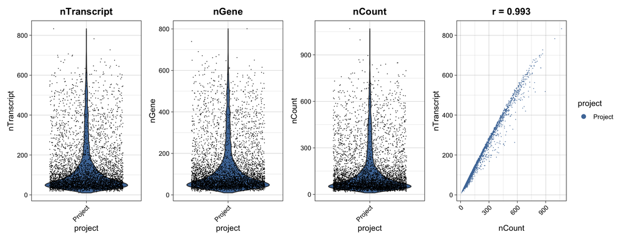

Cell-level QC after transcript filtering. Compare detected isoforms, detected genes, and total isoform counts before choosing cell-filtering thresholds.

```r
PlotCellQC(gbm)
```

Afterwards, `SubsetCells()` can filter cells using these or other `colData` variables. Cells with fewer than 50 detected isoforms are removed below.

```r
gbm <- SubsetCells(object = gbm, subset = nTranscript >= 50)
```

`SubsetCells()` can also be used to subset the object for other purposes. The following are examples of isolating and removing tumor cells from the `cell_type` annotation.

```r
# Isolate tumor cells
gbm_tumor <- SubsetCells(object = gbm, subset = cell_type == "Tumor")

# Remove tumor cells
gbm_notumor <- SubsetCells(object = gbm, subset = cell_type == "Tumor", invert = TRUE)
```

Vectors of cell IDs or active transcript IDs can also be passed through the `cells` and `transcripts` arguments in their respective subset functions.

# 3. Differential analysis

Hypatia provides **3** modules for differential isoform analysis:

- **Isoform Usage**: A measure of isoform *shift*. Identifies differential isoform usage (DIU) events, marked by significant differences in isoform ratios of genes across cell groups.
- **Isoform Diversity**: A measure of isoform *complexity*. Tests differences in gene-level isoform diversity between cell groups. Monoform and polyform classifications provide an additional description of diversity.
- **Isoform Expression**: A measure of isoform *abundance*. Identifies differentially expressed isoforms (DEIs) from cell-level normalized expression values.

| Method | Analysis | Data retrieval | Visualization |
| --- | --- | --- | --- |
| Isoform Usage | `RunDIU()` | `GetUsage()` | `PlotUsage()` |
| Isoform Diversity | `RunDIV()` | `GetDiversity()` | `PlotDiversity()` |
| Isoform Expression | `NormalizeCounts()`, `RunDEI()` | `GetExpression()` | `PlotExpression()` |

Each analysis module has three complementary function families:  
`Run*()` tests differences between cell groups and returns summaries in `$data` and statistical results in `$stats`.  
`Get*()` retrieves summaries for genes or transcripts of interest without testing.  
`Plot*()` visualizes usage, diversity, or expression.

The `Get*()` and `Plot*()` functions take an *SCE* object directly and do not require a preceding `Run*()` analysis.

## Isoform Usage

Isoform usage refers to the relative abundances of transcript isoforms produced by a single gene. The usage of alternative isoforms is reported to vary across cell types, conditions, and developmental stages. Differential isoform usage (DIU) events can reveal regulatory changes, functional diversity, or shifts that are not apparent from gene-level expression alone.

### RunDIU

`RunDIU()` tests whether isoform proportions differ between cell groups, using Pearson’s Chi-square test by default. It also resamples cells 5,000 times to estimate a 95% interval for the transcript with the largest observed proportion difference, keeping that transcript fixed across samples. Differences are calculated as **`group.1 - group.2`**, so positive values indicate higher usage in group 1.

Use `set.seed()` for reproducible results and check `boot.valid.iter` for the number of usable bootstrap samples. See `?RunDIU` for options and guidance on interpreting the intervals.

The tutorial compares Glut and GABA neurons:

```r
set.seed(1024)
glutvsgaba_diu <- RunDIU(gbm, group.1 = "Glut neuron", group.2 = "GABA neuron")
```

Set `permutation = TRUE` to test isoform usage by randomly shuffling cells between groups while keeping group sizes the same. By default, the test uses both the Chi-square statistic (`"chisq"`) and the largest absolute transcript proportion difference (`"max_delta"`). Results include BH-adjusted p-values for each comparison (`padj.perm` and `padj.perm.delta`, respectively), alongside the usual test and bootstrap results.

```r
set.seed(1024)
glutvsgaba_diu_perm <- RunDIU(
  gbm, group.1 = "Glut neuron", group.2 = "GABA neuron",
  permutation = TRUE, perm.iter = 5000
)

significant_diu <- glutvsgaba_diu_perm$stats |>
  dplyr::filter(padj.perm.delta < 0.05, abs(max.prop.diff) > 0.10)
```

This example selects genes with an adjusted maximum-difference permutation p-value below 0.05 and an observed proportion difference above 0.10 in magnitude. The effect-size filter is separate from the test. Use `padj.perm` instead to select genes using the Chi-square permutation test, or set `perm.statistics` to request just one statistic.

More permutations give finer p-value resolution. This test assumes cells can be freely shuffled under the null and does not account for donor or batch structure. See `?RunDIU` for options and interpretation.

**NoteDefining comparisons**

Groups are defined by the active cell grouping or the columns supplied to `group.by`:

- Omit `group.1` and `group.2` to compare each group with all remaining cells.
- Supply only `group.1` to compare that group with all remaining cells.
- Supply multiple labels in `group.1` to pool those cells into one group and compare them with the remaining cells.
- Supply both `group.1` and `group.2` for a direct comparison.
- Multiple grouping columns are combined with `_`.

The examples below are alternatives and are not run in this tutorial.

```r
# Each cell group vs all other cells
all_diu <- RunDIU(gbm)

# Glut neurons vs all other cells
glut_diu <- RunDIU(gbm, group.1 = "Glut neuron")

# Glut and GABA neurons vs all other cells
neur_diu <- RunDIU(gbm, group.1 = c("Glut neuron", "GABA neuron"))

# Glut vs GABA neurons
glutvsgaba_diu <- RunDIU(gbm, group.1 = "Glut neuron", group.2 = "GABA neuron")
```

`RunDIU()` returns a list of two data frames, `$data` and `$stats`:

`glutvsgaba_diu$data`

| group.1 | group.2 | gene | gene.pct.1 | gene.pct.2 | transcript | cts.1 | cts.2 | prop.1 | prop.2 | prop.diff | boot.prop.1 | boot.prop.2 | boot.prop.diff | cell.n.1 | cell.prop.mean.1 | cell.prop.median.1 | cell.prop.sd.1 | cell.prop.iqr.1 | cell.prop.zero.frac.1 | cell.n.2 | cell.prop.mean.2 | cell.prop.median.2 | cell.prop.sd.2 | cell.prop.iqr.2 | cell.prop.zero.frac.2 |
| --- | --- | --- | --- | --- | --- | --- | --- | --- | --- | --- | --- | --- | --- | --- | --- | --- | --- | --- | --- | --- | --- | --- | --- | --- | --- |
| Glut neuron | GABA neuron | AAK1 | 0.175 | 0.209 | AAK1-208 | 13 | 7 | 0.098 | 0.073 | 0.026 | 0.1210, 0.1130, 0.0828, ... (5000 values) | 0.0412, 0.0737, 0.1060, ... (5000 values) | 0.0797, 0.0394, -0.0231, ... (5000 values) | NA | NA | NA | NA | NA | NA | NA | NA | NA | NA | NA | NA |
| Glut neuron | GABA neuron | AAK1 | 0.175 | 0.209 | AAK1-211 | 119 | 89 | 0.902 | 0.927 | -0.026 | 0.879, 0.887, 0.917, ... (5000 values) | 0.959, 0.926, 0.894, ... (5000 values) | -0.0797, -0.0394, 0.0231, ... (5000 values) | NA | NA | NA | NA | NA | NA | NA | NA | NA | NA | NA | NA |
| Glut neuron | GABA neuron | ABCC5 | 0.174 | 0.173 | ABCC5-204 | 62 | 40 | 0.488 | 0.500 | -0.012 | 0.479, 0.473, 0.394, ... (5000 values) | 0.437, 0.486, 0.513, ... (5000 values) | 0.0424, -0.0128, -0.1180, ... (5000 values) | NA | NA | NA | NA | NA | NA | NA | NA | NA | NA | NA | NA |
| Glut neuron | GABA neuron | ABCC5 | 0.174 | 0.173 | ABCC5-205 | 31 | 19 | 0.244 | 0.238 | 0.007 | 0.261, 0.252, 0.257, ... (5000 values) | 0.225, 0.250, 0.218, ... (5000 values) | 0.03520, 0.00191, 0.03890, ... (5000 values) | NA | NA | NA | NA | NA | NA | NA | NA | NA | NA | NA | NA |
| Glut neuron | GABA neuron | ABCC5 | 0.174 | 0.173 | transcript38904.chr3.nic | 5 | 1 | 0.039 | 0.013 | 0.027 | 0.0420, 0.0458, 0.0459, ... (5000 values) | 0.0000, 0.0278, 0.0000, ... (5000 values) | 0.0420, 0.0180, 0.0459, ... (5000 values) | NA | NA | NA | NA | NA | NA | NA | NA | NA | NA | NA | NA |
| Glut neuron | GABA neuron | ABCC5 | 0.174 | 0.173 | transcript39489.chr3.nic | 24 | 20 | 0.189 | 0.250 | -0.061 | 0.168, 0.191, 0.239, ... (5000 values) | 0.338, 0.236, 0.269, ... (5000 values) | -0.1700, -0.0453, -0.0307, ... (5000 values) | NA | NA | NA | NA | NA | NA | NA | NA | NA | NA | NA | NA |

`$data` contains the summarized isoform usage data used to generate the statistical output:

- `group.1` & `group.2`: The two cell groups being compared.
- `gene`: The gene being tested.
- `gene.pct.1`: Fraction of cells in `group.1` with expression of the gene, on the `[0, 1]` scale.
- `gene.pct.2`: Fraction of cells in `group.2` with expression of the gene, on the `[0, 1]` scale.
- `transcript`: The associated transcript.
- `cts.1`: Total counts of the transcript across all cells in `group.1`.
- `cts.2`: Total counts of the transcript across all cells in `group.2`.
- `prop.1`: Transcript proportion for `group.1`.
- `prop.2`: Transcript proportion for `group.2`.
- `prop.diff`: The difference in transcript proportions between groups (`group.1` - `group.2`).
- `cell.n.1`, `cell.n.2`: Number of gene-positive cells used to calculate cell-level transcript-proportion summaries in each group.
- `cell.prop.mean.1`, `cell.prop.mean.2`: Mean cell-level proportion of the transcript among gene-positive cells in each group.
- `cell.prop.median.1`, `cell.prop.median.2`: Median cell-level proportion of the transcript among gene-positive cells in each group.
- `cell.prop.sd.1`, `cell.prop.sd.2`: Sample standard deviation of cell-level transcript proportions in each group.
- `cell.prop.iqr.1`, `cell.prop.iqr.2`: Interquartile range of cell-level transcript proportions in each group.
- `cell.prop.zero.frac.1`, `cell.prop.zero.frac.2`: Fraction of gene-positive cells in which the transcript is not detected in each group.
- `boot.prop.1`, `boot.prop.2`, `boot.prop.diff`: Bootstrap proportion vectors for the transcript. Entries are empty numeric vectors when bootstrapping is disabled.

In the example above, the `cell.*` output columns contain typed `NA` values - set `cell.dispersion = TRUE` to output the optional cell-to-cell summaries.

`glutvsgaba_diu$stats`

| group.1 | group.2 | gene | max.prop.diff | transcript | pval | padj | pval.perm | padj.perm | pval.perm.delta | padj.perm.delta | cramers.v | approx | boot.prop.diff.mean | boot.prop.diff.lower | boot.prop.diff.upper | boot.valid.iter |
| --- | --- | --- | --- | --- | --- | --- | --- | --- | --- | --- | --- | --- | --- | --- | --- | --- |
| Glut neuron | GABA neuron | MEG3 | -0.147 | MEG3-209 | 1.01e-37 | 8.76e-35 | NA | NA | NA | NA | 0.178 | warning | -0.146 | -0.176 | -0.118 | 5000 |
| Glut neuron | GABA neuron | GOLGA8A | -0.225 | GOLGA8A-202 | 1.89e-08 | 8.22e-06 | NA | NA | NA | NA | 0.191 | valid | -0.225 | -0.304 | -0.145 | 5000 |
| Glut neuron | GABA neuron | SNAP25 | -0.161 | SNAP25-201 | 3.77e-05 | 0.0109 | NA | NA | NA | NA | 0.301 | warning | -0.161 | -0.266 | -0.057 | 5000 |
| Glut neuron | GABA neuron | PCLO | -0.299 | PCLO-201 | 7.93e-05 | 0.0173 | NA | NA | NA | NA | 0.331 | warning | -0.297 | -0.404 | -0.187 | 5000 |
| Glut neuron | GABA neuron | CNTN3 | 0.160 | CNTN3-201 | 0.000122 | 0.0213 | NA | NA | NA | NA | 0.360 | warning | 0.161 | 0.036 | 0.320 | 5000 |
| Glut neuron | GABA neuron | CCDC144BP | 0.028 | CCDC144BP-208 | 0.000527 | 0.0764 | NA | NA | NA | NA | 0.077 | valid | 0.028 | 0.010 | 0.046 | 5000 |

`$stats` contains results from statistical tests:

- `group.1` & `group.2`: The two cell groups being compared.
- `gene`: The gene being tested.
- `max.prop.diff`: The signed proportion difference (`group.1` - `group.2`) for the transcript with the greatest absolute difference.
- `transcript`: Transcript associated with the maximum proportion difference.
- `pval`: P-value from the theoretical test selected by `method.use` (uncorrected Pearson Chi-square by default; Fisher is also supported).
- `padj`: Multiple-testing adjusted theoretical p-value, calculated separately for each comparison (default: Benjamini-Hochberg).
- `pval.perm`: Empirical p-value from the uncorrected Pearson Chi-square cell-label permutation test; `NA` when `permutation = FALSE` or `"chisq"` is not requested.
- `padj.perm`: Multiple-testing adjusted empirical Chi-square p-value, calculated separately for each comparison.
- `pval.perm.delta`: Empirical gene-level p-value from cell-label permutation using the maximum absolute transcript proportion difference; `NA` when `permutation = FALSE` or `"max_delta"` is not requested.
- `padj.perm.delta`: Multiple-testing adjusted maximum-delta permutation p-value, calculated separately for each comparison.
- `cramers.v`: Cramer’s V calculated from the uncorrected Pearson Chi-square statistic.
- `approx`: A count-based heuristic: `"valid"` when more than 80% of observed contingency-table counts exceed 5 and all counts are positive; `"warning"` otherwise. This does not check expected counts. Fisher’s test reports `NA`.
- `boot.prop.diff.mean`, `boot.prop.diff.lower`, `boot.prop.diff.upper`: Bootstrap mean and nominal percentile confidence interval for the signed difference of the transcript associated with `max.prop.diff`. Bounds are unavailable with fewer than two finite differences; the mean is unavailable with none. All three values are `NA` when bootstrapping is disabled.
- `boot.valid.iter`: Number of finite bootstrap differences used for the summaries.

### GetUsage

`GetUsage()` quickly retrieves isoform counts and relative abundance from genes of interest. Set `cell.dispersion = TRUE` to include cell-to-cell proportion summaries.

```r
# Usage of MEG3 isoforms for all groups
meg3_usage <- GetUsage(gbm, genes = "MEG3")

# Usage of MEG3 isoforms in Glut and GABA neurons only
meg3_usage_neu <- GetUsage(gbm, genes = "MEG3", group.subset = c("Glut neuron", "GABA neuron"), cell.dispersion = TRUE)
```

`meg3_usage_neu`

| group | gene | gene.pct | transcript | cts | prop | cell.n | cell.prop.mean | cell.prop.median | cell.prop.sd | cell.prop.iqr | cell.prop.zero.frac |
| --- | --- | --- | --- | --- | --- | --- | --- | --- | --- | --- | --- |
| GABA neuron | MEG3 | 0.944 | MEG3-203 | 4 | 0.002 | 370 | 0.003 | 0.000 | 0.027 | 0.0 | 0.989 |
| GABA neuron | MEG3 | 0.944 | MEG3-206 | 13 | 0.006 | 370 | 0.006 | 0.000 | 0.042 | 0.0 | 0.970 |
| GABA neuron | MEG3 | 0.944 | MEG3-209 | 1266 | 0.625 | 370 | 0.614 | 0.631 | 0.278 | 0.3 | 0.078 |
| GABA neuron | MEG3 | 0.944 | MEG3-219 | 1 | 0.000 | 370 | 0.000 | 0.000 | 0.009 | 0.0 | 0.997 |
| GABA neuron | MEG3 | 0.944 | MEG3-220 | 247 | 0.122 | 370 | 0.119 | 0.000 | 0.177 | 0.2 | 0.538 |
| GABA neuron | MEG3 | 0.944 | MEG3-222 | 2 | 0.001 | 370 | 0.002 | 0.000 | 0.028 | 0.0 | 0.995 |

Column descriptions:

- `group`: The group being queried.
- `gene`: The gene being queried.
- `gene.pct`: Fraction of cells in `group` with expression of the gene, on the `[0, 1]` scale.
- `transcript`: The associated transcript.
- `cts`: Total counts of the transcript across cells in `group`.
- `prop`: Transcript proportion.
- `cell.n`: Number of gene-positive cells used for cell-level summaries.
- `cell.prop.mean`, `cell.prop.median`, `cell.prop.sd`, `cell.prop.iqr`: Cell-level transcript-proportion summaries.
- `cell.prop.zero.frac`: Fraction of gene-positive cells in which the transcript is not detected.

### PlotUsage

`PlotUsage()` can be run to visualize isoform proportions after DIU analysis or for general inquiries. Available settings for `plot.type` are ‘stackedbar’, ‘bar’, ‘pie’ and ‘heatmap’.

Bars and pies use the shared categorical palette for transcripts, with pooled `Other` isoforms shown in gray. Heatmaps use a continuous proportion gradient.

Let’s look at the transcript proportions of the gene *MEG3*, which contains top DIU events from several comparisons.

**Stacked bar**

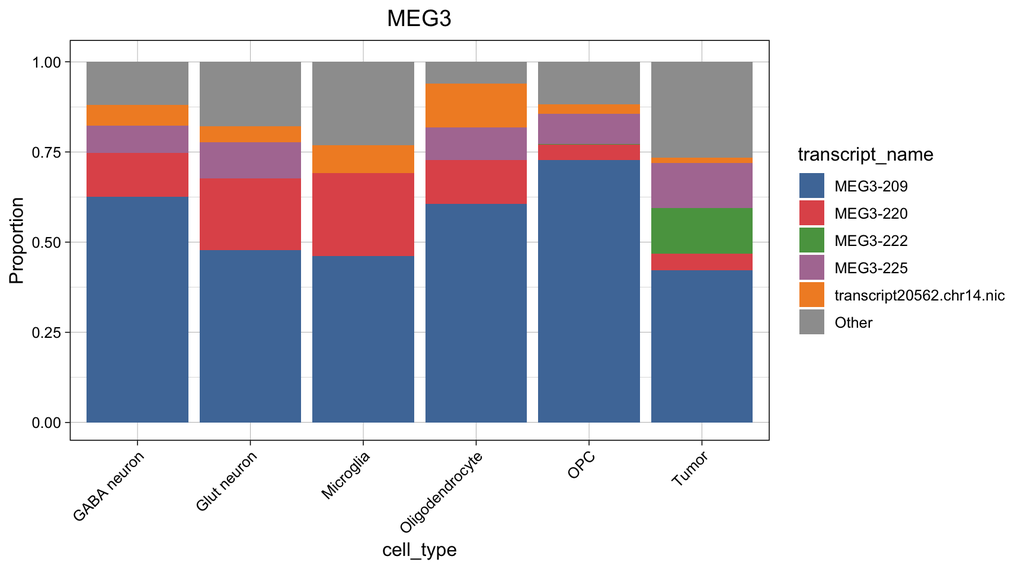

Pooled MEG3 isoform proportions in six cell types. Each stacked bar shows the composition of retained MEG3 counts within one group.

```r
PlotUsage(
  gbm,
  gene = "MEG3",
  group.subset = c("GABA neuron", "Glut neuron", "Microglia", "Oligodendrocyte", "OPC", "Tumor"),
  min.tx.prop = 0.10
)
```

**Heatmap**

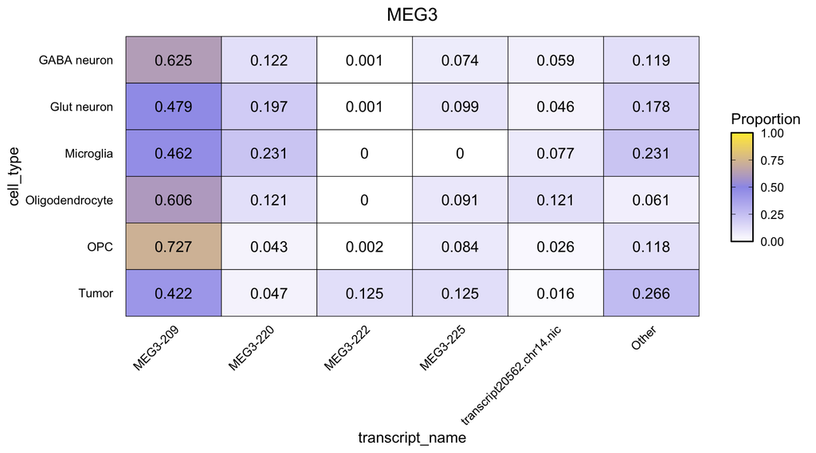

MEG3 isoform proportions shown as a transcript-by-group heatmap. Numeric labels give within-group proportions, not expression counts.

```r
PlotUsage(
  gbm,
  gene = "MEG3",
  plot.type = "heatmap",
  group.subset = c("GABA neuron", "Glut neuron", "Microglia", "Oligodendrocyte", "OPC", "Tumor"),
  min.tx.prop = 0.10,
  show.prop = TRUE
)
```

**Pie**

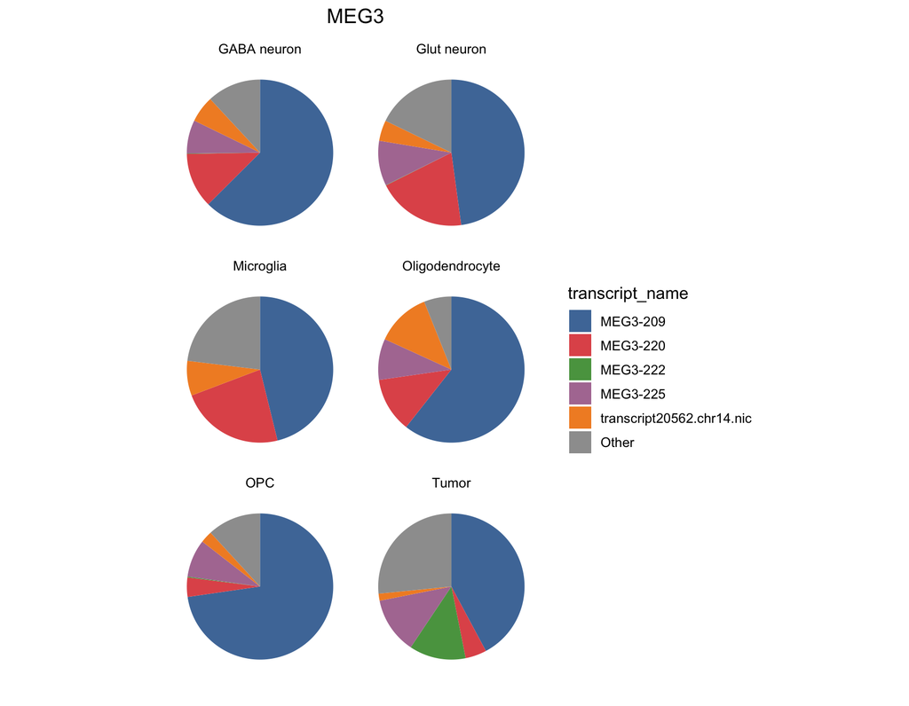

The same pooled MEG3 proportions as pie charts, with one chart per cell type. Slice size represents isoform proportion within each group.

```r
PlotUsage(
  gbm,
  gene = "MEG3",
  plot.type = "pie",
  group.subset = c("GABA neuron", "Glut neuron", "Microglia", "Oligodendrocyte", "OPC", "Tumor"),
  min.tx.prop = 0.10,
  nrow = 3
)
```

**Bar**

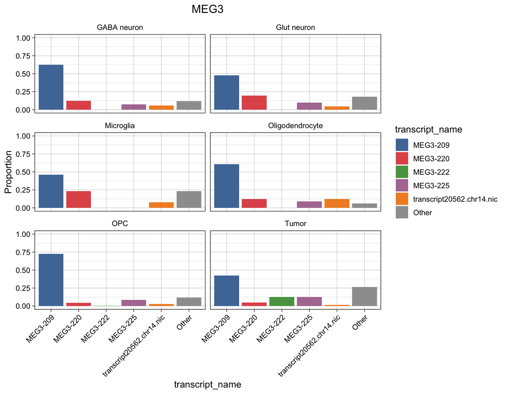

Separate bars show MEG3 isoform proportions within each cell type, making individual transcript contributions easier to compare.

```r
PlotUsage(
  gbm,
  gene = "MEG3",
  plot.type = "bar",
  group.subset = c("GABA neuron", "Glut neuron", "Microglia", "Oligodendrocyte", "OPC", "Tumor"),
  min.tx.prop = 0.10,
  nrow = 3
)
```

## Isoform Diversity

Isoform diversity is a measure of the heterogeneity of transcript isoforms produced by a gene. It provides a useful way to quantify the level of isoform complexity within a gene and to compare how this complexity varies across different cell groups or conditions.

### RunDIV

`RunDIV()` compares isoform diversity between cell groups, using Tsallis entropy by default. It resamples cells 5,000 times and calculates diversity from pooled isoform counts. Differences are calculated as **`group.1 - group.2`**, so positive values indicate greater diversity in group 1.

By default, a difference is supported when at least 97.5% of valid bootstrap differences exceed 0.10 in magnitude in the same direction (`support.thresh = 0.975`, `div.diff.thresh = 0.10`). Choose the difference threshold to suit your diversity measure and biological question. Use `set.seed()` for reproducible results; see `?RunDIV` for other options and interpretation.

Here, each cell group is compared with all remaining cells:

```r
set.seed(1024)
gbm_div <- RunDIV(gbm)
```

Select bootstrap-supported differences using the logical `supported` column:

```r
supported_div <- gbm_div$stats |>
  dplyr::filter(supported)
```

Bootstrap support measures consistency across resampled cells; it is not an adjusted p-value. Check `boot.valid.iter` for the number of valid samples.

Set `permutation = TRUE` to test whether the diversity difference is larger than expected after randomly shuffling cells between groups. Group sizes stay the same, and diversity is calculated from pooled counts. Results include p-values (`pval.perm`) and BH-adjusted p-values (`padj.perm`) for each comparison, alongside bootstrap support.

```r
set.seed(1024)
gbm_div_perm <- RunDIV(gbm, permutation = TRUE, perm.iter = 5000)

significant_div <- gbm_div_perm$stats |>
  dplyr::filter(padj.perm < 0.05, abs(div.diff.observed) > 0.10)
```

This example selects genes with an adjusted p-value below 0.05 and an observed diversity difference above 0.10 in magnitude. The effect-size filter is separate from the test; choose a threshold appropriate to your diversity measure.

Check `perm.valid.iter` for usable shuffles. P-values are `NA` if the original difference or any shuffled difference cannot be calculated. More permutations give finer p-value resolution. This test assumes cells can be freely shuffled under the null and does not account for donor or batch structure. See `?RunDIV` for assumptions and filtering details.

**NoteDefining comparisons**

Groups are defined by the active cell grouping or the columns supplied to `group.by`:

- Omit `group.1` and `group.2` to compare each group with all remaining cells.
- Supply only `group.1` to compare that group with all remaining cells.
- Supply multiple labels in `group.1` to pool those cells into one group and compare them with the remaining cells.
- Supply both `group.1` and `group.2` for a direct comparison.
- Multiple grouping columns are combined with `_`.

The examples below are alternatives and are not run in this tutorial.

```r
# Each cell group vs all other cells
all_div <- RunDIV(gbm)

# Glut neurons vs all other cells
glut_div <- RunDIV(gbm, group.1 = "Glut neuron")

# Glut and GABA neurons vs all other cells
neur_div <- RunDIV(gbm, group.1 = c("Glut neuron", "GABA neuron"))

# Glut vs GABA neurons
glutvsgaba_div <- RunDIV(gbm, group.1 = "Glut neuron", group.2 = "GABA neuron")
```

`RunDIV()` returns a list of two data frames, `$data` and `$stats`.

`gbm_div$data`

| group.1 | group.2 | gene | gene.pct.1 | gene.pct.2 | n.transcripts | div.1 | div.2 | cell.n.1 | cell.div.mean.1 | cell.div.median.1 | cell.div.sd.1 | cell.div.iqr.1 | cell.n.2 | cell.div.mean.2 | cell.div.median.2 | cell.div.sd.2 | cell.div.iqr.2 |
| --- | --- | --- | --- | --- | --- | --- | --- | --- | --- | --- | --- | --- | --- | --- | --- | --- | --- |
| Astrocyte | Microglia,Glut neuron,GABA neuron,Oligodendrocyte,OPC,Tumor,Vascular | ABLIM1 | 0.176 | 0.052 | 4 | 0.1070, 0.0995, 0.0000, ... (5000 values) | 0.302, 0.242, 0.259, ... (5000 values) | NA | NA | NA | NA | NA | NA | NA | NA | NA | NA |
| Astrocyte | Microglia,Glut neuron,GABA neuron,Oligodendrocyte,OPC,Tumor,Vascular | ACSL6 | 0.282 | 0.050 | 4 | 0.135, 0.347, 0.231, ... (5000 values) | 0.225, 0.295, 0.263, ... (5000 values) | NA | NA | NA | NA | NA | NA | NA | NA | NA | NA |
| Astrocyte | Microglia,Glut neuron,GABA neuron,Oligodendrocyte,OPC,Tumor,Vascular | ADD3 | 0.212 | 0.066 | 4 | 0.263, 0.115, 0.000, ... (5000 values) | 0.165, 0.183, 0.189, ... (5000 values) | NA | NA | NA | NA | NA | NA | NA | NA | NA | NA |
| Astrocyte | Microglia,Glut neuron,GABA neuron,Oligodendrocyte,OPC,Tumor,Vascular | AMER2 | 0.129 | 0.115 | 4 | 0, 0, 0, ... (5000 values) | 0.0165, 0.0176, 0.0200, ... (5000 values) | NA | NA | NA | NA | NA | NA | NA | NA | NA | NA |
| Astrocyte | Microglia,Glut neuron,GABA neuron,Oligodendrocyte,OPC,Tumor,Vascular | ANKRD36 | 0.200 | 0.251 | 4 | 0.220, 0.347, 0.233, ... (5000 values) | 0.443, 0.446, 0.443, ... (5000 values) | NA | NA | NA | NA | NA | NA | NA | NA | NA | NA |
| Astrocyte | Microglia,Glut neuron,GABA neuron,Oligodendrocyte,OPC,Tumor,Vascular | APC2 | 0.176 | 0.054 | 2 | 0.0787, 0.1410, 0.0000, ... (5000 values) | 0.0176, 0.0508, 0.0523, ... (5000 values) | NA | NA | NA | NA | NA | NA | NA | NA | NA | NA |

`$data` contains the bootstrapped isoform diversity data used to generate the statistical output:

- `group.1` & `group.2`: The two cell groups being compared.
- `gene`: Gene for which the isoform diversity is computed and compared.
- `gene.pct.1`: Fraction of cells in `group.1` with expression of the gene, on the `[0, 1]` scale (without bootstrapping).
- `gene.pct.2`: Fraction of cells in `group.2` with expression of the gene, on the `[0, 1]` scale (without bootstrapping).
- `n.transcripts`: Number of transcripts retained for the gene after count filtering, before optional `top.n` selection.
- `div.1`: Bootstrapped isoform diversities of the gene for cells in `group.1`.
- `div.2`: Bootstrapped isoform diversities of the gene for cells in `group.2`.
- `cell.n.1`, `cell.n.2`: Number of gene-positive cells used to calculate cell-level diversity summaries in each group.
- `cell.div.mean.1`, `cell.div.mean.2`: Mean cell-level isoform diversity among gene-positive cells in each group.
- `cell.div.median.1`, `cell.div.median.2`: Median cell-level isoform diversity among gene-positive cells in each group.
- `cell.div.sd.1`, `cell.div.sd.2`: Sample standard deviation of cell-level isoform diversity in each group.
- `cell.div.iqr.1`, `cell.div.iqr.2`: Interquartile range of cell-level isoform diversity in each group.

In the example above, the `cell.*` output columns contain typed `NA` values - set `cell.dispersion = TRUE` to output the optional cell-to-cell summaries.

`gbm_div$stats`

| group.1 | group.2 | gene | avgDiv.1 | avgDiv.2 | div.diff | n.effective.1 | n.effective.2 | div.class.1 | div.class.2 | div.diff.lower | div.diff.upper | support.positive | support.negative | boot.valid.iter | supported | div.observed.1 | div.observed.2 | div.diff.observed | pval.perm | padj.perm | perm.valid.iter |
| --- | --- | --- | --- | --- | --- | --- | --- | --- | --- | --- | --- | --- | --- | --- | --- | --- | --- | --- | --- | --- | --- |
| Astrocyte | Microglia,Glut neuron,GABA neuron,Oligodendrocyte,OPC,Tumor,Vascular | SRSF5 | 0.108 | 0.366 | -0.257 | 1 | 2 | monoform | polyform | -0.373 | -0.116 | 0.000 | 0.986 | 5000 | TRUE | 0.115 | 0.366 | -0.252 | NA | NA | NA |
| Astrocyte | Microglia,Glut neuron,GABA neuron,Oligodendrocyte,OPC,Tumor,Vascular | SCD5 | 0.083 | 0.310 | -0.227 | 1 | 1 | monoform | polyform | -0.337 | -0.051 | 0.000 | 0.923 | 5000 | FALSE | 0.088 | 0.310 | -0.222 | NA | NA | NA |
| Astrocyte | Microglia,Glut neuron,GABA neuron,Oligodendrocyte,OPC,Tumor,Vascular | ANKRD36 | 0.261 | 0.445 | -0.184 | 1 | 3 | polyform | polyform | -0.369 | -0.036 | 0.000 | 0.813 | 5000 | FALSE | 0.275 | 0.446 | -0.170 | NA | NA | NA |
| Astrocyte | Microglia,Glut neuron,GABA neuron,Oligodendrocyte,OPC,Tumor,Vascular | ABLIM1 | 0.077 | 0.258 | -0.181 | 1 | 1 | monoform | polyform | -0.295 | -0.006 | 0.000 | 0.846 | 5000 | FALSE | 0.083 | 0.259 | -0.176 | NA | NA | NA |
| Astrocyte | Microglia,Glut neuron,GABA neuron,Oligodendrocyte,OPC,Tumor,Vascular | MAT2A | 0.034 | 0.184 | -0.150 | 1 | 1 | monoform | monoform | -0.203 | -0.068 | 0.000 | 0.897 | 5000 | FALSE | 0.036 | 0.184 | -0.148 | NA | NA | NA |
| Astrocyte | Microglia,Glut neuron,GABA neuron,Oligodendrocyte,OPC,Tumor,Vascular | HNRNPDL | 0.344 | 0.200 | 0.144 | 2 | 1 | polyform | monoform | 0.048 | 0.188 | 0.889 | 0.000 | 5000 | FALSE | 0.356 | 0.200 | 0.156 | NA | NA | NA |

`$stats` contains diversity summaries, bootstrap support, and optional permutation results:

- `group.1` & `group.2`: The two cell groups being compared.
- `gene`: Gene for which the isoform diversity is computed and compared.
- `avgDiv.1`: Average of bootstrapped isoform diversity of the gene for cells in `group.1`.
- `avgDiv.2`: Average of bootstrapped isoform diversity of the gene for cells in `group.2`.
- `div.diff`: Mean finite within-iteration diversity difference (`group.1` - `group.2`).
- `div.diff.lower`, `div.diff.upper`: The 2.5th and 97.5th percentiles of valid bootstrap differences (95% percentile interval).
- `support.positive`, `support.negative`: Fractions of valid differences above `div.diff.thresh` and below `-div.diff.thresh`, respectively.
- `boot.valid.iter`: Number of iterations with finite diversity differences.
- `supported`: Whether either directional support reaches `support.thresh`; `NA` if fewer than two valid differences are available. The function returns all retained genes; use this column to filter supported effects.
- `div.observed.1`, `div.observed.2`: Diversity from the original pooled counts after transcript filtering.
- `div.diff.observed`: Original-data difference (`group.1` - `group.2`) used for permutation testing.
- `pval.perm`, `padj.perm`: Two-sided permutation p-value and adjusted p-value. Values are `NA` when testing is disabled or any required difference cannot be calculated.
- `perm.valid.iter`: Number of usable shuffles; `NA` when permutation testing is disabled.
- `n.effective.1`: Number of effective isoforms for the gene in `group.1`.
- `n.effective.2`: Number of effective isoforms for the gene in `group.2`.
- `div.class.1`: “monoform” when `avgDiv.1` is at or below `entropy.thresh` and “polyform” otherwise.
- `div.class.2`: “monoform” when `avgDiv.2` is at or below `entropy.thresh` and “polyform” otherwise.

With fewer than two finite differences, the interval is unavailable; with none, `div.diff` and support fractions are also unavailable. Genes with no valid differences remain in the bootstrap output so that resampling failures can be inspected.

### GetDiversity

`GetDiversity()` quickly retrieves pooled isoform diversity data for genes of interest. Set `cell.dispersion = TRUE` to include biological cell-to-cell diversity summaries.

```r
# Isoform diversity of gene MT3 for all groups
mt3_div <- GetDiversity(gbm, genes = "MT3")

# Isoform diversity of gene MT3 in OPC cells
mt3_div_opc <- GetDiversity(gbm, genes = "MT3", group.subset = "OPC")

# Shannon isoform diversity of gene MT3 in OPC cells
mt3_shannon_opc <- GetDiversity(gbm, genes = "MT3", group.subset = "OPC", entropy.use = "Shannon", cell.dispersion = TRUE)
```

`mt3_shannon_opc`

| group | gene | gene.pct | n.transcripts | n.effective | transcript | cts | prop | div | div.class | cell.n | cell.div.mean | cell.div.median | cell.div.sd | cell.div.iqr |
| --- | --- | --- | --- | --- | --- | --- | --- | --- | --- | --- | --- | --- | --- | --- |
| OPC | MT3 | 0.152 | 2 | 2 | MT3-201 | 43 | 0.642 | 0.652 | polyform | 54 | 0.037 | 0 | 0.156 | 0 |
| OPC | MT3 | 0.152 | 2 | 2 | MT3-204 | 24 | 0.358 | 0.652 | polyform | 54 | 0.037 | 0 | 0.156 | 0 |

Column descriptions:

- `group`: The cell group being queried.
- `gene`: The gene being queried.
- `gene.pct`: Fraction of cells in `group` with expression of the gene, on the `[0, 1]` scale.
- `n.transcripts`: Number of transcripts retained after count filtering in this group, before optional `top.n` selection.
- `n.effective`: Number of transcripts with within-gene proportion greater than or equal to `prop.thresh`.
- `transcript`: The associated transcript.
- `cts`: Total counts of the transcript in `group`.
- `prop`: The transcript proportion in `group`.
- `div`: Isoform diversity of the gene in `group`.
- `div.class`: `"monoform"` when `div` is at or below `entropy.thresh` and `"polyform"` otherwise.
- `cell.n`: Number of gene-positive cells used for cell-level summaries.
- `cell.div.mean`, `cell.div.median`, `cell.div.sd`, `cell.div.iqr`: Cell-level diversity summaries repeated across the gene’s transcript rows.

### PlotDiversity

`PlotDiversity()` can be used to visualize isoform diversity across groups of cells. The `plot.type` parameter can be one of ‘lollipop’ (default), ‘pcoord’ for parallel coordinate, or ‘density’. The **lollipop** and **pcoord** plot types show the diversity and entropy-based monoform/polyform classification of a few genes, while **density** plots show the distribution of diversity across genes. These plots use pooled transcript counts within each group, rather than the bootstrap means returned by `RunDIV()`.

All three plot types use the same default palette. Colors identify cell groups in lollipop and density plots, and genes in parallel coordinate plots.

**Lollipop**

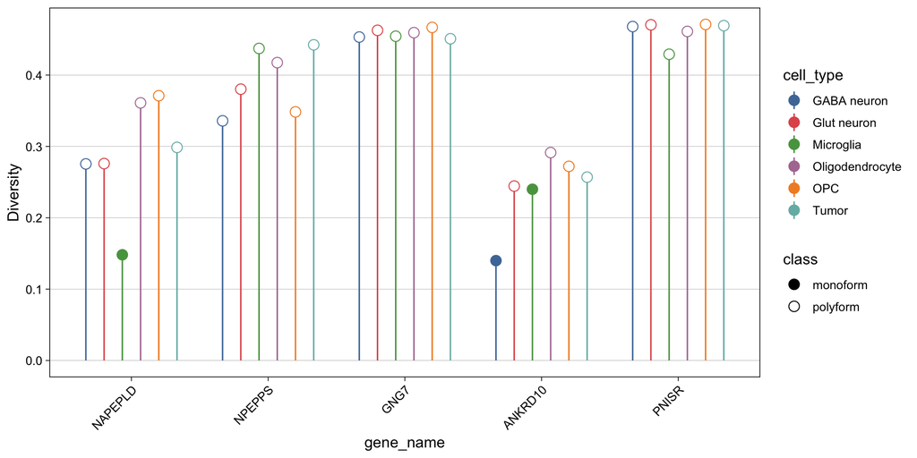

Pooled Tsallis diversity for five example genes across six cell types. Monoform/polyform labels use the entropy threshold rather than a test of differential diversity.

```r
PlotDiversity(
  gbm,
  genes = c("NAPEPLD", "NPEPPS", "GNG7", "ANKRD10", "PNISR"),
  group.subset = c("GABA neuron", "Glut neuron", "Microglia", "Oligodendrocyte", "OPC", "Tumor")
)
```

**Parallel coordinates**

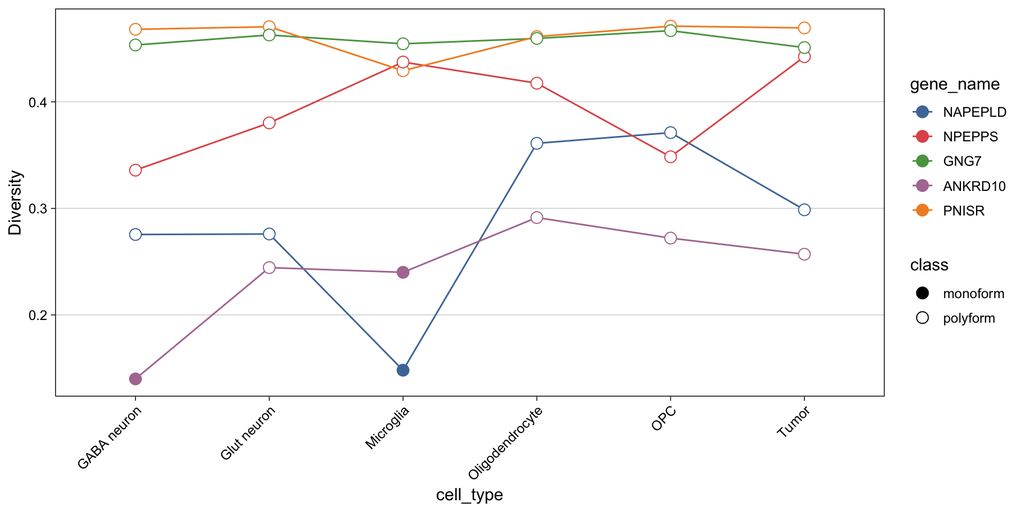

Parallel coordinates connect pooled diversity values for the same gene across cell types, highlighting differences in each gene’s diversity profile.

```r
PlotDiversity(
  gbm,
  genes = c("NAPEPLD", "NPEPPS", "GNG7", "ANKRD10", "PNISR"),
  plot.type = "pcoord",
  group.subset = c("GABA neuron", "Glut neuron", "Microglia", "Oligodendrocyte", "OPC", "Tumor")
)
```

**Density**

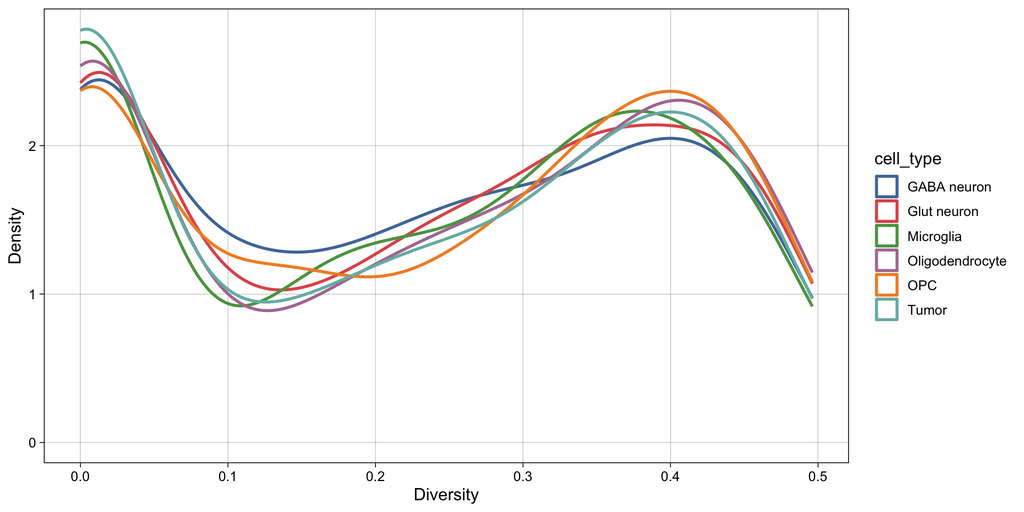

Distributions of pooled gene-level diversity across cell types for genes returned by RunDIV. These curves summarize variation across genes, not across bootstrap iterations or individual cells.

```r
PlotDiversity(
  gbm,
  genes = unique(unlist(gbm_div$data$gene)),
  plot.type = "density",
  group.subset = c("GABA neuron", "Glut neuron", "Microglia", "Oligodendrocyte", "OPC", "Tumor")
)
```

## Isoform Expression

Isoform expression is a measure of the abundance of individual transcript isoforms produced by a gene. Measuring isoform expression allows for a higher-resolution view of gene expression activity, revealing the specific isoforms being produced in different cell types, cell states, conditions, etc. Hypatia adopts log-transformation and Wilcoxon-based testing by default.

### NormalizeCounts

To compare single-cell isoform expression levels, raw counts must first be normalized with `NormalizeCounts()`. By default, counts are divided by the total counts per cell, multiplied by a scale factor, and log1p transformed.

```r
gbm <- NormalizeCounts(gbm)
```

The normalized matrix is stored as “logcounts” in the `assays` slot. Use `assayNames()` to view available count matrices and `assay()` to fetch a specific matrix.

### RunDEI

After normalization, `RunDEI()` can be used to compare isoform expression across cell groups. The default `min.pct = 0.01` requires transcript detection in at least 1% of cells in each group before testing and p-value adjustment. The tutorial compares pooled Glut and GABA neurons with all remaining cells:

```r
# Glut and GABA neurons vs all other cells
neur_dei <- RunDEI(gbm, group.1 = c("Glut neuron", "GABA neuron"))
```

**NoteDefining comparisons**

Groups are defined by the active cell grouping or the columns supplied to `group.by`:

- Omit `group.1` and `group.2` to compare each group with all remaining cells.
- Supply only `group.1` to compare that group with all remaining cells.
- Supply multiple labels in `group.1` to pool those cells into one group and compare them with the remaining cells.
- Supply both `group.1` and `group.2` for a direct comparison.
- Multiple grouping columns are combined with `_`.

The examples below are alternatives and are not run in this tutorial.

```r
# Each cell group vs all other cells
all_dei <- RunDEI(gbm)

# Glut neurons vs all other cells
glut_dei <- RunDEI(gbm, group.1 = "Glut neuron")

# Glut and GABA neurons vs all other cells
neur_dei <- RunDEI(gbm, group.1 = c("Glut neuron", "GABA neuron"))

# Glut vs GABA neurons
glutvsgaba_dei <- RunDEI(gbm, group.1 = "Glut neuron", group.2 = "GABA neuron")
```

`RunDEI()` returns a list of two data frames, `$data` and `$stats`.

`neur_dei$data`

| group.1 | group.2 | gene | transcript | pct.1 | pct.2 | avgExpr.1 | avgExpr.2 | cell.n.1 | cell.expr.median.1 | cell.expr.sd.1 | cell.expr.iqr.1 | cell.n.2 | cell.expr.median.2 | cell.expr.sd.2 | cell.expr.iqr.2 |
| --- | --- | --- | --- | --- | --- | --- | --- | --- | --- | --- | --- | --- | --- | --- | --- |
| Glut neuron,GABA neuron | Microglia,Oligodendrocyte,OPC,Tumor,Astrocyte,Vascular | AAK1 | AAK1-211 | 0.175 | 0.021 | 0.591 | 0.092 | NA | NA | NA | NA | NA | NA | NA | NA |
| Glut neuron,GABA neuron | Microglia,Oligodendrocyte,OPC,Tumor,Astrocyte,Vascular | ABCC5 | ABCC5-204 | 0.091 | 0.021 | 0.307 | 0.094 | NA | NA | NA | NA | NA | NA | NA | NA |
| Glut neuron,GABA neuron | Microglia,Oligodendrocyte,OPC,Tumor,Astrocyte,Vascular | ABCC5 | ABCC5-205 | 0.045 | 0.011 | 0.148 | 0.048 | NA | NA | NA | NA | NA | NA | NA | NA |
| Glut neuron,GABA neuron | Microglia,Oligodendrocyte,OPC,Tumor,Astrocyte,Vascular | ABHD2 | ABHD2-201 | 0.097 | 0.023 | 0.314 | 0.097 | NA | NA | NA | NA | NA | NA | NA | NA |
| Glut neuron,GABA neuron | Microglia,Oligodendrocyte,OPC,Tumor,Astrocyte,Vascular | ACADSB | ACADSB-201 | 0.045 | 0.011 | 0.150 | 0.048 | NA | NA | NA | NA | NA | NA | NA | NA |
| Glut neuron,GABA neuron | Microglia,Oligodendrocyte,OPC,Tumor,Astrocyte,Vascular | ACSF3 | ACSF3-203 | 0.021 | 0.011 | 0.064 | 0.050 | NA | NA | NA | NA | NA | NA | NA | NA |

`$data` contains the summarized expression data used to generate the statistical output:

- `group.1` & `group.2`: The two cell groups being compared.
- `gene`: The gene associated with the transcript being tested.
- `transcript`: The transcript being tested.
- `pct.1`: Fraction of cells in `group.1` with expression of the transcript, on the `[0, 1]` scale.
- `pct.2`: Fraction of cells in `group.2` with expression of the transcript, on the `[0, 1]` scale.
- `avgExpr.1`: Average expression of the transcript across all cells in `group.1`, on the selected assay’s scale (`logcounts` by default).
- `avgExpr.2`: Average expression of the transcript across all cells in `group.2`, on the selected assay’s scale (`logcounts` by default).
- `cell.n.1`, `cell.n.2`: Number of cells used to calculate cell-level expression summaries in each group.
- `cell.expr.median.1`, `cell.expr.median.2`: Median cell-level expression in each group.
- `cell.expr.sd.1`, `cell.expr.sd.2`: Sample standard deviation of cell-level expression in each group.
- `cell.expr.iqr.1`, `cell.expr.iqr.2`: Interquartile range of cell-level expression in each group.

In the example above, the `cell.*` output columns contain typed `NA` values - set `cell.dispersion = TRUE` to output the optional cell-to-cell summaries.

`neur_dei$stats`

| group.1 | group.2 | gene | transcript | log2FC | pval | padj |
| --- | --- | --- | --- | --- | --- | --- |
| Glut neuron,GABA neuron | Microglia,Oligodendrocyte,OPC,Tumor,Astrocyte,Vascular | MEG3 | MEG3-209 | 3.049 | 0.00e+00 | 0.00e+00 |
| Glut neuron,GABA neuron | Microglia,Oligodendrocyte,OPC,Tumor,Astrocyte,Vascular | MEG3 | MEG3-220 | 5.468 | 0.00e+00 | 0.00e+00 |
| Glut neuron,GABA neuron | Microglia,Oligodendrocyte,OPC,Tumor,Astrocyte,Vascular | PKD1 | PKD1-201 | 3.323 | 1.40e-265 | 2.29e-262 |
| Glut neuron,GABA neuron | Microglia,Oligodendrocyte,OPC,Tumor,Astrocyte,Vascular | MIR124-2HG | MIR124-2HG-212 | 5.018 | 6.70e-240 | 1.09e-236 |
| Glut neuron,GABA neuron | Microglia,Oligodendrocyte,OPC,Tumor,Astrocyte,Vascular | MEG3 | MEG3-225 | 4.255 | 4.59e-202 | 7.49e-199 |
| Glut neuron,GABA neuron | Microglia,Oligodendrocyte,OPC,Tumor,Astrocyte,Vascular | RAP1GAP | RAP1GAP-211 | 3.913 | 3.77e-199 | 6.15e-196 |

`$stats` contains results from the statistical tests:

- `group.1` & `group.2`: The two cell groups being compared.
- `gene`: The gene associated with the transcript being tested.
- `transcript`: The transcript being tested.
- `log2FC`: `log2(avgExpr.1 / avgExpr.2)` on the selected assay, without a pseudocount. With the default `logcounts` assay, this is the log2 ratio of mean log-normalized values, not a fold change calculated from untransformed counts.
- `pval`: P-value from the Wilcoxon rank-sum test.
- `padj`: Adjusted p-value, calculated separately for each group comparison (default: Bonferroni, `p.adj = "bonferroni"`).

### GetExpression

`GetExpression()` quickly obtains an expression summary for isoforms or genes of interest.

```r
# Expression of MEG3-209 for all groups
meg3_209 <- GetExpression(gbm, transcripts = "MEG3-209")

# Expression of MEG3-209 in neurons
meg3_209_neu <- GetExpression(gbm, transcripts = "MEG3-209", group.subset = c("Glut neuron", "GABA neuron"))

# Expression of all MEG3 isoforms in neurons
meg3_neu <- GetExpression(gbm, genes = "MEG3", group.subset = c("Glut neuron", "GABA neuron"), cell.dispersion = TRUE)
```

`meg3_neu`

| group | gene | transcript | pct | avgExpr | cell.n | cell.expr.median | cell.expr.sd | cell.expr.iqr |
| --- | --- | --- | --- | --- | --- | --- | --- | --- |
| GABA neuron | MEG3 | MEG3-203 | 0.010 | 0.038 | 392 | 0.000 | 0.376 | 0.000 |
| GABA neuron | MEG3 | MEG3-206 | 0.028 | 0.094 | 392 | 0.000 | 0.563 | 0.000 |
| GABA neuron | MEG3 | MEG3-209 | 0.870 | 3.972 | 392 | 4.522 | 1.645 | 1.081 |
| GABA neuron | MEG3 | MEG3-219 | 0.003 | 0.008 | 392 | 0.000 | 0.162 | 0.000 |
| GABA neuron | MEG3 | MEG3-220 | 0.436 | 1.585 | 392 | 0.000 | 1.839 | 3.458 |
| GABA neuron | MEG3 | MEG3-222 | 0.005 | 0.018 | 392 | 0.000 | 0.251 | 0.000 |

Column descriptions:

- `group`: The cell group being queried.
- `gene`: The (associated) gene being queried.
- `transcript`: The transcripts being queried.
- `pct`: Fraction of cells in `group` with expression of the transcript, on the `[0, 1]` scale.
- `avgExpr`: Average expression of the transcript across all cells in `group`.
- `cell.n`: Number of cells used to calculate cell-level expression summaries.
- `cell.expr.median`, `cell.expr.sd`, `cell.expr.iqr`: Median, sample standard deviation, and interquartile range of cell-level expression.

To retrieve the expression matrix without summary statistics, users can combine `assay()` with `SubsetCells()` and `SubsetTranscripts()`. The following example retrieves the normalized expression matrix for isoforms of the gene *MBP* in oligodendrocytes:

```r
# Subset the object
oligod <- SubsetCells(gbm, cell_type == "Oligodendrocyte")
oligod_mbp <- SubsetTranscripts(oligod, subset = gene_name == "MBP")

# Get the matrix
assay(oligod_mbp, "logcounts")
```

### PlotExpression

`PlotExpression()` can be used to visualize isoform expression. The `plot.type` setting can be set to ‘violin’ (default), ‘reducedDim’ or ‘heatmap’. First, select the top 3 DEIs with higher mean log-normalized expression in the pooled neuronal group than in the remaining cells. The violin and reduced-dimension plots below use these transcripts.

**Violin**

**Top 3 neuron DEIs**

```r
# Get the top 3 DEIs of neurons
neur_top3_dei <- neur_dei$stats |>
  dplyr::filter(log2FC > 0.6 & padj < 0.05) |>
  dplyr::slice_min(padj, n = 3, with_ties = FALSE) |>
  dplyr::pull(transcript)

neur_top3_dei
## [1] "MEG3-209" "MEG3-220" "PKD1-201"
```

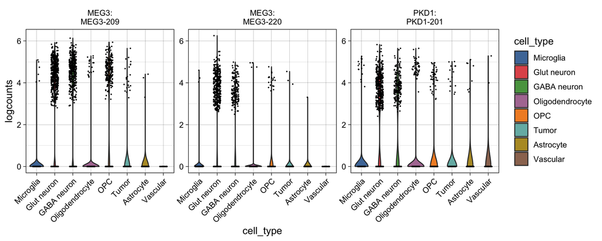

Cell-level log-normalized expression of three selected neuronal DEIs across cell types. Violin shapes summarize the distributions; overlaid points represent individual cells.

```r
# Violin plot
PlotExpression(
  gbm,
  transcripts = neur_top3_dei,
  plot.type = "violin"
)
```

**Reduced dimensions**

For the **reducedDim** plot, 2D embeddings are required. Recall that `umap_1` and `umap_2` were included in the cell-level metadata when preparing the input data. These embeddings are stored in `reducedDims`, then selected with `dim.use`. Hypatia uses the supplied embedding; it does not calculate a new UMAP.

```r
# Add UMAP embeddings from the prepared colData
reducedDim(gbm, "UMAP") <- colData(gbm)[, c("umap_1", "umap_2")]
```

**NoteAlternative: use a Seurat embedding**

This alternative requires your own Seurat object and is not run here:

```r
reducedDim(gbm, "UMAP") <- seurat_object@reductions$umap@cell.embeddings[colnames(gbm), , drop = FALSE]
```

**Top 3 neuron DEIs**

```r
# Get the top 3 DEIs of neurons
neur_top3_dei <- neur_dei$stats |>
  dplyr::filter(log2FC > 0.6 & padj < 0.05) |>
  dplyr::slice_min(padj, n = 3, with_ties = FALSE) |>
  dplyr::pull(transcript)

neur_top3_dei
## [1] "MEG3-209" "MEG3-220" "PKD1-201"
```

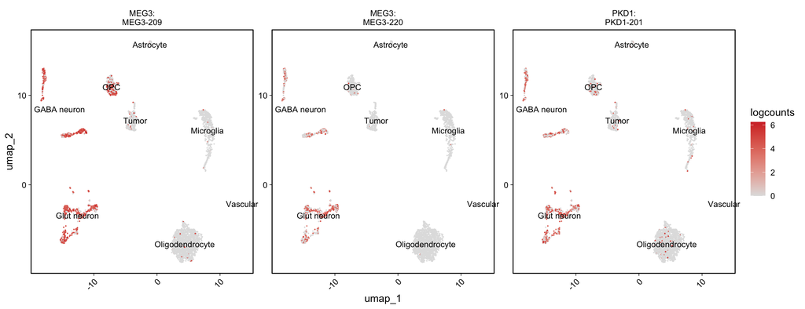

Expression of the same three neuronal DEIs overlaid on the supplied gene-expression UMAP. Each panel colors cells by a transcript’s log-normalized expression.

```r
# reducedDim plot
PlotExpression(
  gbm,
  transcripts = neur_top3_dei,
  plot.type = "reducedDim",
  dim.use = "UMAP"
)
```

**Heatmap**

The **heatmap** is best used to visualize multiple DEIs. Let’s plot the top 20 DEIs from the *Glut* vs *GABA* neurons comparison.

**Top 20 Glut vs GABA DEIs**

```r
# Compare Glut and GABA neurons for this heatmap
glutvsgaba_dei <- RunDEI(gbm, group.1 = "Glut neuron", group.2 = "GABA neuron")

# Get the top 20 Glut vs GABA DEIs
glutvsgaba_top20 <- glutvsgaba_dei$stats |>
  dplyr::filter(abs(log2FC) >= 0.6 & padj <= 0.05) |>
  dplyr::slice_min(padj, n = 20, with_ties = FALSE) |>
  dplyr::arrange(dplyr::desc(log2FC)) |>
  dplyr::pull(transcript)

glutvsgaba_top20
##  [1] "MAST3-209"      "NPTX1-201"      "AGRN-202"       "SYT7-201"
##  [5] "GRM2-202"       "SLC6A7-201"     "NECAB1-201"     "NIPAL2-201"
##  [9] "KCNIP4-IT1-201" "KIAA0930-212"   "KIAA0930-201"   "IGSF9B-206"
## [13] "GOLGA8A-204"    "RAP1GAP-211"    "MEG3-220"       "ADCYAP1R1-202"
## [17] "DNER-201"       "DGKD-201"       "NRIP3-201"      "SLC6A1-211"
```

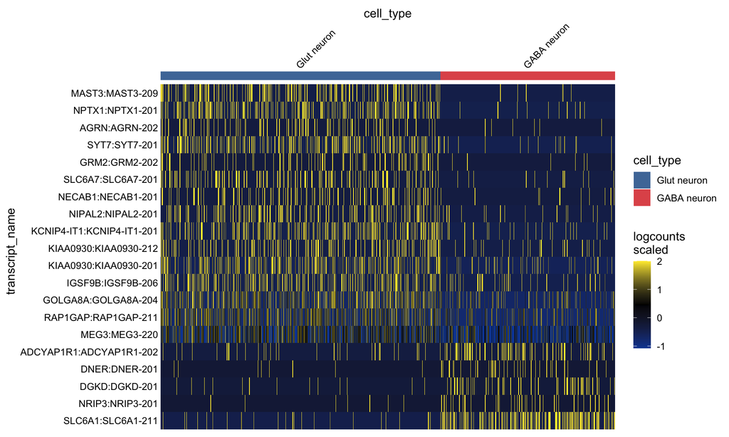

Twenty selected DEIs in Glut and GABA neurons. Each transcript’s log-normalized expression is standardized across plotted cells and clipped to [-2, 2], emphasizing relative expression patterns rather than absolute abundance.

```r
# Heatmap
PlotExpression(
  gbm,
  transcripts = glutvsgaba_top20,
  plot.type = "heatmap",
  group.subset = c("Glut neuron", "GABA neuron")
)
```

# Extras

#### Preparing cell-level metadata (extended)

The following shows how the cell-level metadata (`gbm_colData` from the example) was prepared from a *Seurat* object from gene expression analysis.

```r
# Get the cell_type ident
gbm_colData <- seurat_object[[]][, "cell_type", drop = FALSE]

# Get umap_1 and umap_2 from the standard workflow
gbm_colData <- cbind(gbm_colData, seurat_object@reductions$umap@cell.embeddings)

# Match row name order with count matrix
gbm_colData <- gbm_colData[colnames(gbm_countData), , drop = FALSE]
```

#### Preparing transcript-level metadata (extended)

Below shows how the transcript-level metadata (`gbm_rowData` from the example) was prepared. The GTF from the *IsoQuant* output, reference genome GTF, and *SQANTI* results were used.

```r
# Read in SQANTI3 classifications
sqanti_class <- readr::read_delim("OUT.extended_annotation_classification.txt")

# Read in reference GTF
ref <- rtracklayer::import("GRCh38-2024-A.gtf")
ref <- ref |>
  as.data.frame() |>
  dplyr::filter(type == "transcript") |>
  dplyr::select(transcript_id, transcript_name, gene_id, gene_name) |>
  dplyr::distinct()

# build rowData
gbm_rowData <- sqanti_class |>
  dplyr::select(isoform, structural_category, associated_gene, RTS_stage, within_CAGE_peak, within_polyA_site) |>
  dplyr::filter(isoform %in% rownames(gbm_countData)) |>
  dplyr::rename("gene_id" = "associated_gene",
                "transcript_id" = "isoform") |>
  dplyr::left_join(dplyr::distinct(ref[, c("gene_name", "gene_id")]), by = "gene_id") |>
  dplyr::left_join(dplyr::distinct(ref[, c("transcript_name", "transcript_id")]), by = "transcript_id") |>
  dplyr::mutate(transcript_name = ifelse(is.na(transcript_name), transcript_id, transcript_name),
                gene_name = ifelse(is.na(gene_name), gene_id, gene_name)) |>
  tibble::column_to_rownames(var = "transcript_id")

# Match row name order with count matrix
gbm_rowData <- gbm_rowData[rownames(gbm_countData), , drop = FALSE]
```

#### Multiple samples

To analyze multiple samples in Hypatia, a separate *SCE* object can be created for each sample, or raw isoform count matrices can be combined into a single object after aligning transcript IDs and ensuring unique cell IDs across samples. Transcript IDs must refer to consistent isoform definitions across samples. Cell- and transcript-level metadata must include every cell and transcript ID in the combined count matrix; `CreateSCE()` reorders the metadata as needed. Separate objects support separate analyses; cross-sample comparisons within a single Hypatia call require a combined object.

Store sample identity and relevant annotations in the cell metadata. Multiple `group.by` variables, such as `group.by = c("cell_type", "sample_id")` or `group.by = c("cell_type", "condition")`, define groups from the observed combinations of those annotations, with labels joined by `_` (for example, `Astrocyte_control`). Use `group.1` and `group.2` to select specific comparisons, such as the same cell type in two conditions. Otherwise, each group is compared with the remaining cells; exactly two groups produce one comparison.

This grouping does not perform batch correction or account for biological replication. In particular, including `sample_id` in `group.by` defines sample-specific groups but does not model between-sample variability. Condition-level inference across biological samples requires a replicate-aware statistical approach.

#### Session information

**R and package versions**

```r
sessionInfo()
## R version 4.5.2 (2025-10-31)
## Platform: aarch64-apple-darwin20
## Running under: macOS Tahoe 26.1
##
## Matrix products: default
## BLAS:   /System/Library/Frameworks/Accelerate.framework/Versions/A/Frameworks/vecLib.framework/Versions/A/libBLAS.dylib
## LAPACK: /Library/Frameworks/R.framework/Versions/4.5-arm64/Resources/lib/libRlapack.dylib;  LAPACK version 3.12.1
##
## locale:
## [1] en_US.UTF-8/en_US.UTF-8/en_US.UTF-8/C/en_US.UTF-8/en_US.UTF-8
##
## time zone: America/Chicago
## tzcode source: internal
##
## attached base packages:
## [1] stats     graphics  grDevices utils     datasets  methods   base
##
## other attached packages:
## [1] Hypatia_1.5.0
##
## loaded via a namespace (and not attached):
##  [1] generics_0.1.4              tidyr_1.3.2
##  [3] SparseArray_1.10.2          lattice_0.22-7
##  [5] digest_0.6.39               magrittr_2.0.4
##  [7] evaluate_1.0.5              grid_4.5.2
##  [9] RColorBrewer_1.1-3          fastmap_1.2.0
## [11] jsonlite_2.0.0              Matrix_1.7-4
## [13] ggnewscale_0.5.2            GenomeInfoDb_1.46.2
## [15] backports_1.5.0             httr_1.4.7
## [17] purrr_1.2.1                 SingleCellExperiment_1.32.0
## [19] UCSC.utils_1.6.1            scales_1.4.0
## [21] abind_1.4-8                 cli_3.6.5
## [23] rlang_1.1.7                 XVector_0.50.0
## [25] Biobase_2.70.0              withr_3.0.2
## [27] DelayedArray_0.36.0         yaml_2.3.11
## [29] S4Arrays_1.10.0             tools_4.5.2
## [31] checkmate_2.3.3             dplyr_1.2.0
## [33] ggplot2_4.0.1               matrixTests_0.2.3.1
## [35] SummarizedExperiment_1.40.0 BiocGenerics_0.56.0
## [37] vctrs_0.7.1                 R6_2.6.1
## [39] matrixStats_1.5.0           stats4_4.5.2
## [41] lifecycle_1.0.5             Seqinfo_1.0.0
## [43] S4Vectors_0.48.0            htmlwidgets_1.6.4
## [45] IRanges_2.44.0              pkgconfig_2.0.3
## [47] pillar_1.11.1               gtable_0.3.6
## [49] glue_1.8.0                  xfun_0.60
## [51] tibble_3.3.1                GenomicRanges_1.62.0
## [53] tidyselect_1.2.1            MatrixGenerics_1.22.0
## [55] knitr_1.50                  farver_2.1.2
## [57] htmltools_0.5.8.1           patchwork_1.3.2
## [59] labeling_0.4.3              rmarkdown_2.30
## [61] compiler_4.5.2              S7_0.2.1
```